# crop_bbox slides

#### How to preprocess the input images containing human bodies?

对于一个特定视觉识别或定位任务，使用一个已知神经网络模型进行训练，并不是一个无脑的“调参”工作

但有时候我们期望通过盲目地调参，来使模型效果更好，这主要因为：

1.我们对于神经网络的拟合功能 还不够深入理解 我们对卷积操作对于数据提取的特征到底是什么还不够清晰 （比如不同尺度下，相同的卷积操作对于相同图像提取的特征是否存在本质的区别？）

2.我们对训练数据集与测试数据集中，数据分布与标签噪声对模型拟合产生的影响，还不能准确控制，(单纯的mini-batch真的就是好的？)

3.我们对于，将原始数据，该预处理成何种形式，才能让神经网络模型更加鲁棒地寻找数据中一致模式，并同时具备良好泛化能力的问题 ，缺少深入思考。

而以上这些环节，相比与模型本身什么结构来讲，同样重要，所以也不一定要一味地追求一个花里胡哨 、千篇一律的网络结构设计

接下来我主要来讨论关于人体姿态估计对于数据预处理的问题！

```python
import cv2
from PIL import Image
import torch
import torchvision.transforms as transforms
import matplotlib.pyplot as plt
import json
```

针对人体姿态关键点回归问题 一般由两种方式： 对于自上而下的方式，将多人的姿态估计问题，通过目标检测手段，转换为单人姿态估计问题。 其主要方法就是，通过目标检测，得到图像中可能是人体的bbox，然后将该区域作为网络输入，进行训练与测试！

拿在COCO_val2017数据上的 人体 bbox （ Average Precision : AP=0.56）的结果，来分析自上而下方法的网络输入应该怎么设计！ ：）

```python
detection_bbox_file="COCO_val2017_detections_AP_H_56_person.json"
with open(detection_bbox_file,'r') as bbox_file:
    annot=json.loads(bbox_file.readline())
```

```python
print(annot[0])

#统计图像id
img_list=[]
for i in annot:
    if i['image_id'] not in img_list:
        img_list.append(i['image_id'])

img_id=annot[0]['image_id']
print("img_id:",str(img_id))
print(img_list[0],img_list[1])
```

```
{'score': 0.9992738366127014, 'image_id': 532481, 'bbox': [249.8199079291458, 175.21093805640606, 74.00419360691592, 55.626325589288854], 'category_id': 1}
img_id: 532481
532481 66231
```

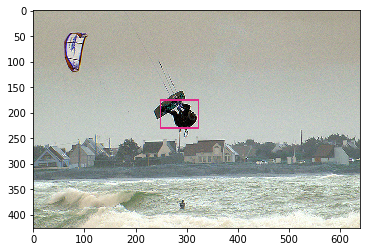

```
[249.8199079291458, 175.21093805640606, 74.00419360691592, 55.626325589288854]
```

```python
img_cv=cv2.imread(str(img_id).zfill(12)+'.jpg')
img=Image.open(str(img_id).zfill(12)+'.jpg')
pos=annot[0]['bbox']

a,b=max(0,pos[0]),max(0,pos[1])
c,d=min(img.size[1],pos[0]+pos[2]),min(img.size[0],pos[1]+pos[3])

cv2.rectangle(img_cv, (int(a),int(b)), (int(c),int(d)), (226,43,138), 2)
#img=Image.fromarray(cv2.cvtColor(img_cv,cv2.COLOR_BGR2RGB))
#img.save(str(img_id)+'_x.jpg')
plt.imshow(img_cv)
plt.show()
print(pos)
```

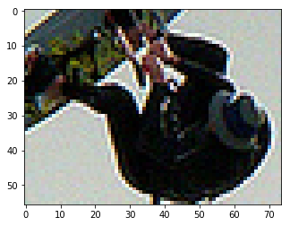

```
74 56
```

```python
#crop(PIL.Image,y,x,h,w) ！! note the order
img=transforms.functional.crop(img,pos[1],pos[0],pos[3],pos[2])
plt.imshow(img)
plt.show()
print(img.size[0],img.size[1])
```

```
padding:91,100,91,100
```

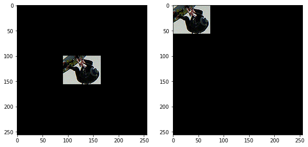

```python
input_resolution=256
x_pad=256-img.size[0]
y_pad=256-img.size[1]
left_pad=int(x_pad/2)
up_pad=int(y_pad/2)
print("padding:{},{},{},{}".format(left_pad,up_pad,x_pad-left_pad,y_pad-up_pad))
Padding1=transforms.Compose([transforms.Pad((left_pad,up_pad,x_pad-left_pad,y_pad-up_pad))])
Padding2=transforms.Compose([transforms.Pad((0,0,x_pad,y_pad))])
img1=Padding1(img)
img2=Padding2(img)
fig=plt.figure(figsize=(10,10))
fig.add_subplot(1,2,1)

plt.imshow(img1)
fig.add_subplot(1,2,2)
plt.imshow(img2)

plt.show()
```

如何确定网络的输入尺寸大小？这个需要参考数据集中人体大小的下限和上限

考虑到：COCO keypoints不考虑32x32大小以下的，那么32x32可以作为人体尺寸的下限

那么，我们可以统计以下数据集中bbox的尺寸来确定上限

```python
import json
import numpy as np
with open('person_keypoints_val2017.json','r') as json_file:
            preds = json.loads(json_file.readline())
invisible_num_keypoints=0
total_keypoints=0
total_labeled_people=0
total_people=0
half_labeled_people=0
bbox_w_max=0
bbox_h_max=0
bbox_w_max_id=0
bbox_h_max_id=0
max_area=0
for i in preds['annotations']:

    total_people += 1
    if  i['num_keypoints'] != 0 and i['area'] > max_area:
        max_area = i['area']
        max_area_id = i['image_id']
        max_area_w=i['bbox'][2]
        max_area_h = i['bbox'][3]
        kp = i['keypoints']
    if i['num_keypoints'] != 0 and i['bbox'][2] > bbox_w_max:
        bbox_w_max = i['bbox'][2]
        bbox_w_max_id = i['image_id']
        w_max__area=i['area']
        h = i['bbox'][3]
    if i['num_keypoints'] != 0 and  i['bbox'][3]>bbox_h_max:
        bbox_h_max=i['bbox'][3]
        bbox_h_max_id=i['image_id']
        h_max__area=i['area']
        w = i['bbox'][2]
    if i['num_keypoints'] != 0:

        total_labeled_people += 1
        total_keypoints = total_keypoints + i['num_keypoints']

        if i['num_keypoints'] <= 8:
            half_labeled_people += 1

        keypoints=(i['keypoints'])
        keypoints=np.array(keypoints).reshape(-1,3)
        for p in keypoints:
            if p[2]==1:

                invisible_num_keypoints += 1
                #print(p)

                #print('image_id:{},id:{}'.format(i["image_id"],i['id']))

print("总人数 = {}".format(total_people))
print("有标记总人数 = {}".format(total_labeled_people))
print("部分标记(<8)的点 = {}".format(half_labeled_people))
print("总标记点 = {}".format(total_keypoints))
print("不可见的标记点 = {}".format(invisible_num_keypoints))
print("有标记人数 / 总人数 = {} ".format(float(total_labeled_people)/float(total_people)))
print("部分标记人数 / 标记人数 = {}".format(float(half_labeled_people)/float(total_labeled_people)))
print("不可见点 / 总标记点 = {}".format((float(invisible_num_keypoints)/float(total_keypoints))))

print("bbox_w_max = {}, id={}, area={},h={}".format(bbox_w_max,bbox_w_max_id,w_max__area,h))
print("bbox_h_max = {}, id={}, area={},w={}".format(bbox_h_max,bbox_h_max_id,h_max__area,w))
print("max_area = {}, id = {}, w={}, h={}".format(max_area,max_area_id,max_area_w,max_area_h))
```

```
总人数 = 11004
有标记总人数 = 6352
部分标记(<8)的点 = 1861
总标记点 = 68215
不可见的标记点 = 8365
有标记人数 / 总人数 = 0.5772446383133406
部分标记人数 / 标记人数 = 0.2929785894206549
不可见点 / 总标记点 = 0.12262698819907646
bbox_w_max = 640, id=214869, area=235886.27775,h=471.37
bbox_h_max = 640, id=276018, area=36036.7234,w=130.88
max_area = 266844.89135, id = 343706, w=640, h=487.09
```

```
[51.54, 210.61, 270.61, 352.21]
[264.03, 301.51, 44.22, 223.14]
[100.93, 132.12, 59.16, 103.93]
[294.48, 160.94, 46.75, 94.16]
[500.19, 159.68, 50, 93.34]
[122, 44.91, 312.8, 412.9]
```

[figure not shown]

```python
imgs=[bbox_w_max_id,bbox_h_max_id,max_area_id]
imgs=[39914,463542,64718]
### draw bboxes  and keypoints in imgs
part_labels = ['nose','eye_l','eye_r','ear_l','ear_r',
               'sho_l','sho_r','elb_l','elb_r','wri_l','wri_r',
               'hip_l','hip_r','kne_l','kne_r','ank_l','ank_r']
part_idx = {keypoint_name:idx for idx, keypoint_name in enumerate(part_labels)}

def draw_limbs(inp, pred,BGR):  #pred=[x1,y1,1,x2,y2,1,...,x17,y17,1]
    def link(a, b, color):
        if part_idx[a] < pred.shape[0] and part_idx[b] < pred.shape[0]:

            a = pred[part_idx[a]]     #[x,y,1]
            b = pred[part_idx[b]]     #[x,y,1]

            if a[2]>0.07 and b[2]>0.07:
                cv2.line(inp, (int(a[0]), int(a[1])), (int(b[0]), int(b[1])), color, 2,cv2.LINE_AA)

    pred = np.array(pred).reshape(-1, 3)   #array([[x1,y1,1],[],[x17,y17,1]]]
    bbox = pred[pred[:,2]>0]
    a, b, c, d = bbox[:,0].min(), bbox[:,1].min(), bbox[:,0].max(), bbox[:,1].max()

    #cv2.rectangle(inp, (int(a), int(b)), (int(c), int(d)), (255, 255, 255), 1)
    (B,G,R) = BGR
    link('nose', 'eye_l', (B,G,R))
    link('eye_l', 'eye_r', (B,G,R))
    link('eye_r', 'nose', (B,G,R))

    link('eye_l', 'ear_l', (B,G,R))
    link('eye_r', 'ear_r', (B,G,R))

    link('ear_l', 'sho_l', (B,G,R))
    link('ear_r', 'sho_r', (B,G,R))
    link('sho_l', 'sho_r', (B,G,R))
    link('sho_l', 'hip_l', (B,G,R))
    link('sho_r', 'hip_r',(B,G,R))
    link('hip_l', 'hip_r', (B,G,R))

    link('sho_l', 'elb_l', (B,G,R))
    link('elb_l', 'wri_l', (B,G,R))

    link('sho_r', 'elb_r', (B,G,R))
    link('elb_r', 'wri_r', (B,G,R))

    link('hip_l', 'kne_l', (B,G,R))
    link('kne_l', 'ank_l', (B,G,R))

    link('hip_r', 'kne_r', (B,G,R))
    link('kne_r', 'ank_r', (B,G,R))

fig=plt.figure(figsize=(50,50))
for idx,img_id in enumerate(imgs):
    img_xxx=cv2.imread('E:/yangsen/ysstronger/pose/val2017/'+str(img_id).zfill(12)+'.jpg')
    for i in preds['annotations']:
        if img_id == i['image_id'] and i['num_keypoints'] !=0 :
            keypoints=i['keypoints']
            pos=i['bbox']
            print(pos)
            a,b=max(0,pos[0]),max(0,pos[1])
            c,d=min(img_xxx.shape[1],pos[0]+pos[2]),min(img_xxx.shape[0],pos[1]+pos[3])
            B,G,R=int(a*255/img_xxx.shape[1]),int(b*255/img_xxx.shape[0]),int(d*165/img_xxx.shape[0])
            draw_limbs(img_xxx,keypoints,(B,G,R))
            cv2.rectangle(img_xxx, (int(a),int(b)), (int(c),int(d)), (B,G,R), 3)
            #cv2.putText(img_xxx, 'score:{}'.format(1), (int(a),int(b)+20), cv2.FONT_HERSHEY_TRIPLEX, 1, (255, 255, 0), 1, False)
    cv2.imwrite(str(img_id)+'.jpg',img_xxx)
    fig.add_subplot(1,len(imgs),idx+1)
    img_xxx=cv2.cvtColor(img_xxx, cv2.COLOR_BGR2RGB)
    plt.imshow(img_xxx)
plt.show()
#img=Image.fromarray(cv2.cvtColor(img_cv,cv2.COLOR_BGR2RGB))
#img.save(str(img_id)+'_x.jpg')
```

1. 根据结果可以看出val2017 大尺度的人体在600x600附近 像素区域较大 一般的3x3卷积或者5x5卷积提取低层特征 难度较大 。
2. 根据以往的经验，模型在96x96以上的人体尺寸表现较良好

那么， 我们可以先设置 256x256 大小的输入，对于大尺寸的人体采取缩小的操作（信息损失较少），小尺寸的人体采取上采样（是直接插值法还是，弥补细节插值法？）